# Introduction to deep learning

## Benny Avelin

[figure not shown]

By Glosser.ca - Own work, Derivative of File:Artificial neural network.svg, [CC BY-SA 3.0](https://creativecommons.org/licenses/by-sa/3.0), [Link](https://commons.wikimedia.org/w/index.php?curid=24913461)

# Overview (session 1)

- Brief history of the subject
- What is the perceptron algorithm?
- What is known about the perceptron algorithm?
- How does this relate to modern neural networks?
  - What is a neural network?

# Brief history of the subject

- Inspired by working theories of the brain, Pitts and McCulloch (1943) developed a "Threshold Logic Unit (TLU)" as a way to describe an artificial neuron. Using binary inputs and outputs:

$$ h(x) = \begin{cases} +1 & \text{ if } w \cdot x \geq b \\ 0 & otherwise \end{cases} $$

For $x \in \{0,1\}^n$ and $w \in \mathbb{R}^n$, $b \in \mathbb{R}$. One says that the "neuron" that is represented by $h$ "fires" if $h=1$. $w$ is the weights and $b$ is usually called the bias (threshold).

# Brief history of the subject

[figure not shown]

  By Source (WP:NFCC#4), Fair use, [Link](https://en.wikipedia.org/w/index.php?curid=47541432)

# Perceptron algorithm

The perceptron algorithm is a binary classifier and the idea is to "learn/find" the weights such that it maps its input to the correct class (1 or 0).

**Given:** Points $x_1,\ldots, x_N$ in $\mathbb{R}^n$, with a corresponding label $y_1,\ldots, y_N$ being either 1 or 0.

**Goal:** Find the weights $w$ and bias $b$ such that $h(x_i) = y_i$ for $i=1,\ldots,n$, if possible.

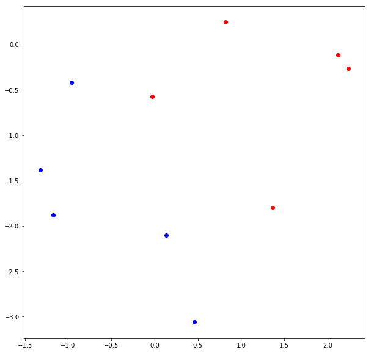

```python
%matplotlib inline
import matplotlib.pyplot as plt
plt.figure(figsize=(10,10))
plt.scatter(X1[:,0],X1[:,1], color='red')
plt.scatter(X2[:,0],X2[:,1], color='blue')
```

# Perceptron algorithm

To simplify notation, raise the dimension and let the first coordinate of $x$ be $1$, then rearrange the weights such that the bias corresponds to the first component, then

1. Initialize the weights $w_0$ to some initial value.
2. For each data point $x_j$ in our data set do:
   1. Compute the "error" $$ e_j = (y_j - h_{w_t}(x_j)) $$
   2. Update the weights $$ w_{t+1} = w_t + \sum_{j=1}^n e_j \cdot x_j $$
3. If the error $\sum_j |e_j|$ is too large goto step 2.

```python
HTML(anim.to_html5_video())
```

[video not shown]

> **Theorem:** If the dataset is linearly separable then the perceptron algorithm is guaranteed to converge in a finite number of steps.
- What if the dataset is not linearly separable? Complete failure of training.
- Do we have stability, no there will be $\infty$ many solutions.

```python
HTML(anim.to_html5_video())
```

[video not shown]

# Problems

- No convergence for non linearly-separable data.
- No stability
- The initial creators thought in terms of boolean functions, i.e. can we express
  - AND / OR ? Yes
  - Minsky and Papert remarked in 1969 that you cannot represent XOR with a perceptron, i.e. $$ A \oplus B $$
- Can't we express more complicated functions by making networks of TLU's?
  - Yes, but how do we train them?

# Stability

- 1987 Krauth and Mezard published a paper solving the stability problem.
- As it turns out this is essentially equivalent to Vapnik and Chervonenkis Support Vector Machine invented in 1963.
- Cortes and Vapnik considered the soft margin in 1995.

## Support vector machine

Consider the decision boundary for the perceptron $$ w \cdot x - b = 0. $$ Introducing a margin we can actually look at $$ y_i(w \cdot x_i - b) \geq 1. $$

Solve $$ \text{min} \|w\|^2 \text{ subject to } y_i (w \cdot x_i - b) \geq 1 \text{ for all } i = 1,\ldots, n. $$

# Soft margin relaxation

$$ \left[\frac 1 n \sum_{i=1}^n \max\left(0, 1 - y_i(\vec{w} \cdot \vec{x}_i - b)\right) \right] + \lambda\lVert \vec{w} \rVert^2 $$

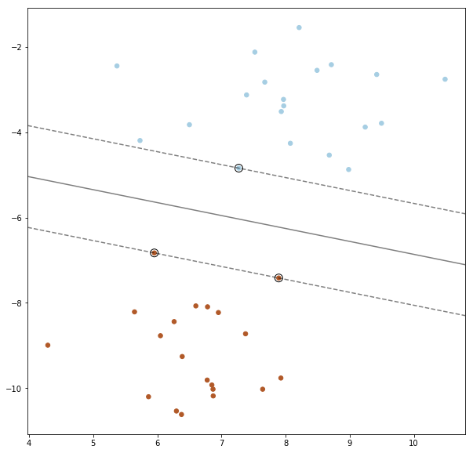

```python
plot_svm()
```

# Modern neural networks

- The main difference is that the heaviside function is replaced by a smooth "activation" function, usually the so called sigmoid $$ \sigma(x) = \frac{1}{1+e^{-x}} $$
- An LTU where we replace the activation with $\sigma$ is called an artificial neuron.

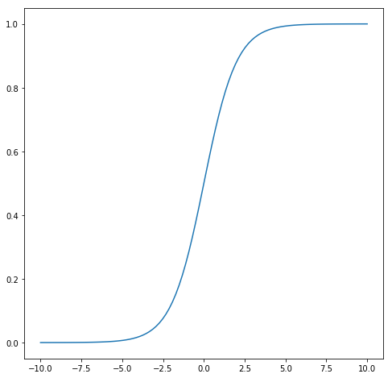

```python
plt.figure(figsize=(8,8))
plt.plot(x,y)
plt.show()
```

A single artificial neuron can then be represented as $$ h(x) = \sigma(w \cdot x + b) $$ If we have a loss function $L(w,b)$ then we could try to find $w,b$ such that $$ \min_{w,b} L(w,b) $$ if we assume $L$ to be convex and $C^1$ then we can try to find the minima with **gradient descent**.

The updates are if we begin at some $w_0,b_0$ $$ w_{i+1} = w_i - \alpha \nabla_w L(w_i,b_i) $$ $$ b_{i+1} = b_i - \alpha \nabla_b L(w_i,b_i) $$

for a step size $\alpha$ (learning rate).

Simple choice of $L(w,b)$ is $$ L(w,b) = \frac{1}{n} \sum_{i=1}^n (y_i - h_{w,b}(x_i))^2, \quad \text{quadradic loss}. $$

this is the same that is used in standard linear regression.

For classification another common choice is the cross entropy loss, which is the inverse of the sigmoid (logistic)

$$ L(w,b) = \sum_{i=1}^n -\log \left ( (1-h(x_i))^{1-y_i} h(x_i)^{y_i} \right ) $$

Let us make the interpretation that $h_{w,b}(x_i) = P(y = 1 | x_i;w,b)$ then the above expression can be rewritten as $$ L(w,b) = \sum_{i=1}^n -\log \left ( P(y = y_i|x_i;w,b) \right ) $$ which is - the log-likelihood. So there is now a connection to a well known concept in statistics, namely logistic regression. I.e. a single artificial neuron with the sigmoid activation function and the cross-entropy loss is logistic regression.

We can make more complicated models by adding more neurons, i.e. let us consider: $$ f(x) = \sum_{j=1}^k v^j h_{w^j,b^j}(x) $$

this is what is known as a feed forward neural network with a single hidden layer.

[figure not shown]

In the context of neural networks we let $\sigma: \mathbb{R} \to \mathbb{R}$ and with $\sigma(x)$ where $x \in \mathbb{R}^n$ we apply componentwise. Denote

$$W^T = (w^1,\ldots, w^k)$$$$B^T = (b_1,\ldots,b_k)$$$$v^T = (v_1,\ldots,v_k)$$

then we can write $f$ as $$ f(x) = v^T \sigma(Wx+B) $$

In fact if we introduce $W^{(1)},B^{(1)},W^{(2)},B^{(2)}$ we can consider

$$ \begin{align} f^{(1)}(x) &= \sigma(W^{(1)} x + B^{(1)})\\ f^{(2)}(x) &= \sigma(W^{(2)} f^{(1)}(x) + B^{(2)}) \\ f(x) &= v^T f^{(2)}(x) \end{align} $$

[figure not shown]